# **results: King County subgraphs**

## **Reading phylogenetic subgraphs**

I first read the taxa that are part of King County phylogenetic subgraphs:

```r
require(data.table)
require(phangorn)
require(ggplot2)
require(reshape)

#   working directory with phyloscanner output
home <- '~/Box Sync/OR_Work/Seattle'
indir.phsc  <- file.path(home,'analysis_191017','phyloscanner')

#   extract subgraph taxa
infiles <- data.table(F=list.files(indir.phsc, pattern='rda$', full.names=TRUE, recursive=TRUE))
infiles <- subset(infiles, grepl('datedsubgraphs',F))
#   SELECT defines if KC, KCHSX, KCMSM
infiles[, SELECT:= gsub('^(.*)subgraphs_([A-Z]+)\\.rda','\\2',basename(F))]
#   for subtype B, I ran separate analyses based on very large subtrees for comp efficiency
#   ST stores the subtype, and ST_CLADE the large subtree
infiles[, ST:= gsub('^.*Subtype([^_]+)_.*\\.rda','\\1',basename(F))]
infiles[, ST_CLADE:= as.integer(gsub('[^c]*c([0-9]+)','\\1',ST))]
infiles[, ST:= gsub('([^c]*)c([0-9]+)','\\1',ST)]
#   ID of bootstrap replicate, 000 for analysis on real alignment
infiles[, REP:= gsub('^.*ndrm_([0-9]+)_.*\\.rda','\\1',basename(F))]
dsubgraphtaxa <- infiles[, {
            #i<- 1
            #infile <- infiles[i, F]
            infile <- F
            cat('Process',infile,'\n')
            load(infile)
            subgraph.names <- unlist(sapply( subgraphs, function(subgraph)  rep(subgraph$subgraph.name, length(subgraph$tip.label)) ))
            subgraph.taxa <- unlist(sapply( subgraphs, function(subgraph)  subgraph$tip.label))
            list(   NAME=subgraph.names,
                    TAXA= subgraph.taxa
            )
        }, by=c('ST','ST_CLADE','REP','SELECT')]
```

[output not shown]

[output cut: 17 more lines]

```r
#   add meta data from taxa names
regex.tip.label <- '^([A-Z]+)_+PR/RT-([0-9]+)_([0-9]+)_([a-zA-Z]+)_([a-zA-Z]+)_([a-zA-Z]+)_([a-zA-Z]+)_([a-zA-Z_]+)_([0-9]+)$'
dsubgraphtaxa[, ID:= as.numeric(gsub(regex.tip.label,'\\3',TAXA))]
dsubgraphtaxa[, SEQ_YEAR:= as.numeric(gsub(regex.tip.label,'\\9',TAXA))]
dsubgraphtaxa[, FULL_NAME:= paste0(ST,'_',REP,'_',SELECT,'_',NAME)]
```

## **Adding meta-data**

Next, I add meta-data on the individuals:

```r
infile.meta <- file.path(home,'analysis_191017','misc','180709_sequence_labels.rda')

#   add meta data from pre-processed persons file
load(infile.meta)
dind <- as.data.table(dind)
setnames(dind, c('newnum','b_yr','birthCountry2','county','race2','transm2','Gender2'), c('ID','BIRTH_YEAR2','BIRTH_COUNTRY2','COUNTY','RACE2','TRANSM2','GENDER2'))
tmp <- subset(dind, select=c(ID,BIRTH_YEAR2,BIRTH_COUNTRY2,COUNTY,RACE2,TRANSM2,GENDER2))
set(tmp, NULL, 'BIRTH_YEAR2', tmp[, as.numeric(BIRTH_YEAR2)])
dsubgraphtaxa <- merge(dsubgraphtaxa,tmp,by='ID')
dsubgraphtaxa[, AGE2020:= cut(2020-BIRTH_YEAR2, breaks=c(-Inf,20,25,30,35,40,45,50,55,60,Inf))]
```

## **Distribution of subgraph sizes**

Let us first have a look on the distribution of subgraph sizes, that is how many individuals there are in partially observed, separate transmission chains. (The transmission chains are partially observed because we do not have sequence data from everyone).

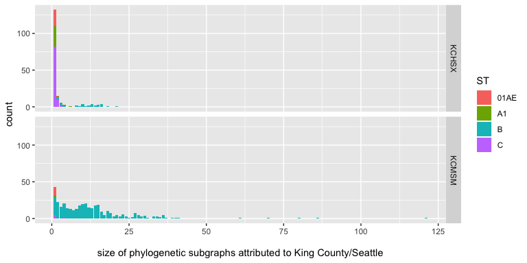

```r
dsubgraphsize <- dsubgraphtaxa[, list(SIZE=length(ID)), by=c('ST','REP','SELECT','NAME')]
dsubgraphsize[, SINGLETON:= as.character(factor(SIZE==1, levels=c(TRUE,FALSE), labels=c('subgraph size 1','subgraph size >1')))]
ggplot(subset(dsubgraphsize, SELECT!='KC'), aes(x=SIZE, fill=ST)) +
        geom_bar() +
        facet_grid(SELECT~.) +
        labs(x='\nsize of phylogenetic subgraphs attributed to King County/Seattle')
```

## **Sample size for phylodynamic analysis of HIV spread in Seattle**

Next, let us have a look at how individuals are in subtrees are of size 1 and size >1. The number of individuals in subgraphs of size > 1 can be informative about transmission dynamics within Seattle.

```r
#   number of individuals in subgraphs of size == 1 or size > 1
dsubgraphind <- dsubgraphsize[, list(N_INDIVIDUALS=sum(SIZE)), by=c('ST','REP','SELECT','SINGLETON')]
dsubgraphind <- dcast.data.table(dsubgraphind, ST+REP+SINGLETON~SELECT,value.var='N_INDIVIDUALS')
dsubgraphind
```

```
#>      ST REP        SINGLETON   KC KCHSX KCMSM
#> 1: 01AE 000  subgraph size 1   34    22    11
#> 2: 01AE 000 subgraph size >1   23     2    NA
#> 3:   A1 000  subgraph size 1   39    28     4
#> 4:   A1 000 subgraph size >1   52    12     8
#> 5:    B 000  subgraph size 1   43    NA    23
#> 6:    B 000 subgraph size >1 5687   351  4684
#> 7:    C 000  subgraph size 1   95    82     5
#> 8:    C 000 subgraph size >1  134    29     4
```

## **Empirical analysis on group-mixing within subgraphs**

Next, I was interested to quantify the extent of mixing across certain population groups, based on the subgraphs of size > 1. So let us select just those:

```r
#   number of individuals in subgraphs of size == 1 or size > 1
tmp <- subset(dsubgraphsize, SIZE>1, c(ST, REP, SELECT, NAME))
dsubgraphtaxa2 <- merge(dsubgraphtaxa, tmp, by=c('ST','REP','SELECT','NAME'))
```

### **Ethnicity**

First, I considered ethnicity.

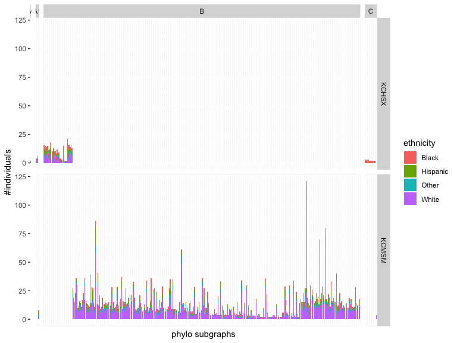

```r
dsubgraphtaxa2[, DUMMY:= RACE2]
dcnt <- dsubgraphtaxa2[, list(N= length(ID)), by=c('FULL_NAME','SELECT','ST','DUMMY')]
tmp <- dsubgraphtaxa2[, list(TOTAL= length(ID)), by=c('FULL_NAME','SELECT','ST')]
dcnt <- merge(dcnt, tmp, by=c('FULL_NAME','SELECT','ST'))
ggplot(subset(dcnt, SELECT!='KC'), aes(x=FULL_NAME, y=N, fill=DUMMY)) +
        geom_bar(stat='identity') +
        labs(y='#individuals',x='phylo subgraphs',fill='ethnicity') +
        theme(axis.text.x=element_blank(), axis.ticks.x=element_blank()) +
        facet_grid(SELECT~ST, scale='free_x', space='free_x')
```

We previously found for non-B subtypes that the subgraphs were homogeneous by ethnicity. However, the large majority of patients are subtype B, and it now seems that there is considerable mixing by ethnicity.

Let us quantify this. As a measure of mixing, I quantified average homogeneity of each subgraph [as described here](https://stats.stackexchange.com/questions/221332/variance-of-a-distribution-of-multi-level-categorical-data), as well as the average of the largest frequency of any strata:

```r
tmp <- dcnt[, list(R= sum( (N/TOTAL)^2), PMAX= max(N/TOTAL) ), by=c('FULL_NAME','SELECT','ST')]
tmp[, list(R_AVG=mean(R), PMAX_AVG=mean(PMAX)), by=c('SELECT')]
```

```
#>    SELECT     R_AVG  PMAX_AVG
#> 1:  KCHSX 0.5825993 0.6468089
#> 2:     KC 0.5367842 0.6528626
#> 3:  KCMSM 0.5372799 0.6598397
```

The results suggest that

### **Place of birth**

Second, I considered place of birth.

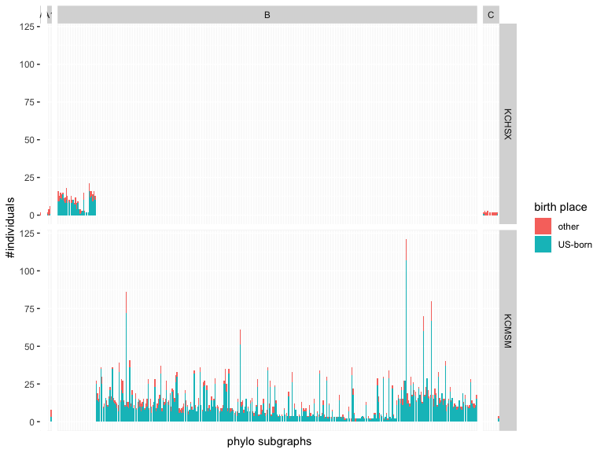

```r
dsubgraphtaxa2[, DUMMY:= as.character(factor(BIRTH_COUNTRY2=='USA',levels=c(TRUE,FALSE),labels=c('US-born','other')))]
dcnt <- dsubgraphtaxa2[, list(N= length(ID)), by=c('FULL_NAME','SELECT','ST','DUMMY')]
tmp <- dsubgraphtaxa2[, list(TOTAL= length(ID)), by=c('FULL_NAME','SELECT','ST')]
dcnt <- merge(dcnt, tmp, by=c('FULL_NAME','SELECT','ST'))
ggplot(subset(dcnt, SELECT!='KC'), aes(x=FULL_NAME, y=N, fill=DUMMY)) +
        geom_bar(stat='identity') +
        labs(y='#individuals',x='phylo subgraphs',fill='birth place') +
        theme(axis.text.x=element_blank(), axis.ticks.x=element_blank()) +
        facet_grid(SELECT~ST, scale='free_x', space='free_x')
```

```r
tmp <- dcnt[, list(R= sum( (N/TOTAL)^2), PMAX= max(N/TOTAL) ), by=c('FULL_NAME','SELECT','ST')]
tmp[, list(R_AVG=mean(R), PMAX_AVG=mean(PMAX)), by=c('SELECT')]
```

```
#>    SELECT     R_AVG  PMAX_AVG
#> 1:  KCHSX 0.7621123 0.8177296
#> 2:     KC 0.7686190 0.8432554
#> 3:  KCMSM 0.7752652 0.8491030
```

The results suggest that

- mixing is more pronounced in terms of ethnicity compared to place of birth.

### **Age group**

Third, I considered age brackets for comparison.

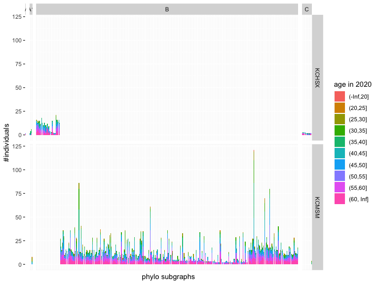

```r
dsubgraphtaxa2[, DUMMY:= AGE2020]
dcnt <- dsubgraphtaxa2[, list(N= length(ID)), by=c('FULL_NAME','SELECT','ST','DUMMY')]
tmp <- dsubgraphtaxa2[, list(TOTAL= length(ID)), by=c('FULL_NAME','SELECT','ST')]
dcnt <- merge(dcnt, tmp, by=c('FULL_NAME','SELECT','ST'))
ggplot(subset(dcnt, SELECT!='KC'), aes(x=FULL_NAME, y=N, fill=DUMMY)) +
        geom_bar(stat='identity') +
        labs(y='#individuals',x='phylo subgraphs',fill='age in 2020') +
        theme(axis.text.x=element_blank(), axis.ticks.x=element_blank()) +
        facet_grid(SELECT~ST, scale='free_x', space='free_x')
```

```r
tmp <- dcnt[, list(R= sum( (N/TOTAL)^2), PMAX= max(N/TOTAL) ), by=c('FULL_NAME','SELECT','ST')]
tmp[, list(R_AVG=mean(R), PMAX_AVG=mean(PMAX)), by=c('SELECT')]
```

```
#>    SELECT     R_AVG  PMAX_AVG
#> 1:  KCHSX 0.3643044 0.4227299
#> 2:     KC 0.2972718 0.3815802
#> 3:  KCMSM 0.2857450 0.3762270
```

I am not clear how to interpret the results in comparison to ethnicity or place of birth, because there are many more age groups.